# Dallas Crimes Report 2016

##### PRID: KALEE26404

### Summary

The full analysis of the provided data has been undertaken and a report has been produced considering all the variants. The conclusion has been drawn at the end of this analysis.

### Table of Contents

#### 1 Introduction

#### 2 Analysis

###### 2.1 Descriptive Statistics

###### 2.2 Summay Statistics

###### 2.3 Visulization

#### 3 Conclusion

#### 4 Refrences

#### 5 Appendix

### 1 Introduction:

Dallas city crime data was provided for the year 2016. Reporting the crime without bias and based of correct figures had always been a challenge due to social and political influence. In this report we can look for some key trends of crimes reported in Dallas for the year 2016 and will highlight the hidden trends of police behavior in dealing with suspects by considering their gender and race ref[1]. The full analysis of the data in a graphic format has been provided below.

### 2 Analysis

##### 2.1 Descriptive Statistics:

The statistics covered in below table are for two numerical variables (OFFICER_YEARS_ON_FORCE and BEAT) from the give data set:

- mean
- median
- standard deviation (sd)
- minimum (min)
- maximum (max)
- range

|  | mean | median | sd | min | max | range |
| --- | --- | --- | --- | --- | --- | --- |
| OFFICER_YEARS_ON_FORCE | 8.049098 | 6 | 7.562481 | 0 | 36 | 36 |
| BEAT | 392.772556 | 351 | 210.461375 | 111 | 757 | 646 |

In the above table we can see that averge no of officer years on force are 8.04 with minimum 0 number of years and maximum years.

##### 2.2 Summary Statistics:

In the below chart we can that crime cases reported in central division was much higher as 23.6% in comparison to north west which was just 8.05% ref[1].  
#### ————————— Division based distribution of Crime Reports —————————

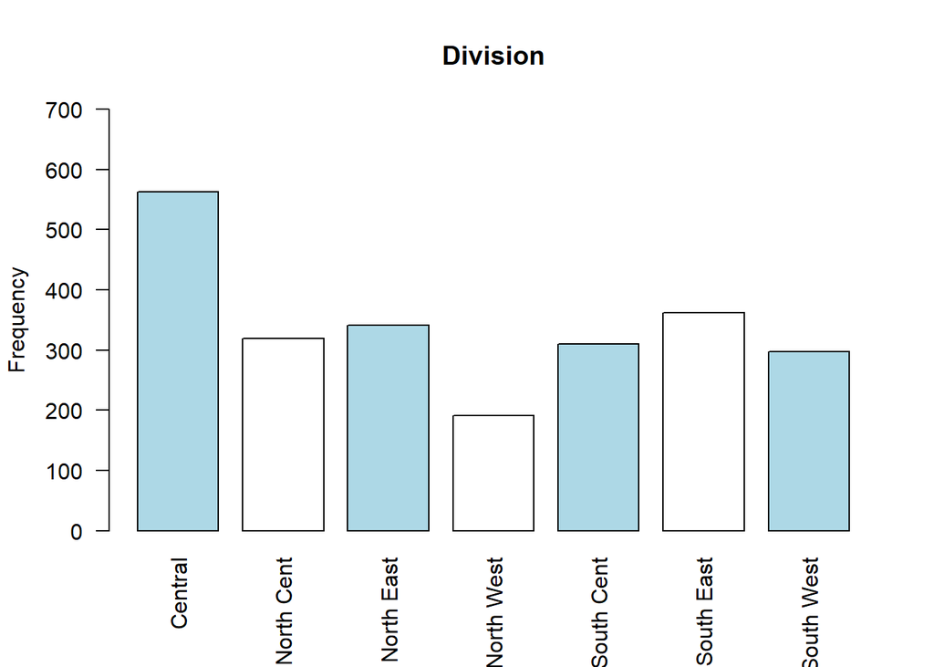

```
##
##       CENTRAL NORTH CENTRAL     NORTHEAST     NORTHWEST SOUTH CENTRAL
##     23.625682     13.386488     14.309694      8.015107     13.008812
##     SOUTHEAST     SOUTHWEST
##     15.190936     12.463282
```

In the below chart we can see the distribution of data based on officers gender. It was found that 89.9% of male officer and just 10.07% of female officer had handled the crime in 2016 ref[1].

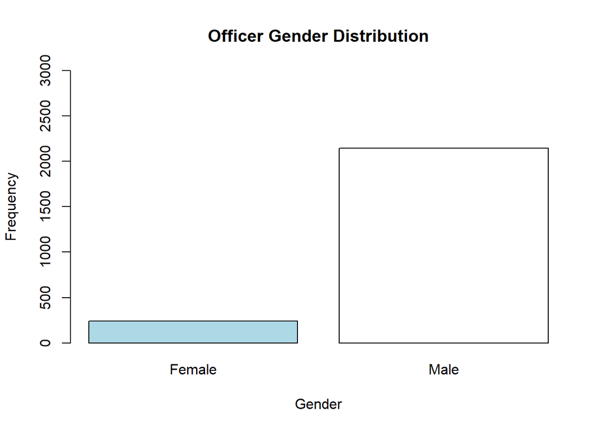

###### Summary Statistics of **OFFICER_GENDER** variable: ref[1]

```
##
##   Female     Male
## 10.07134 89.92866
```

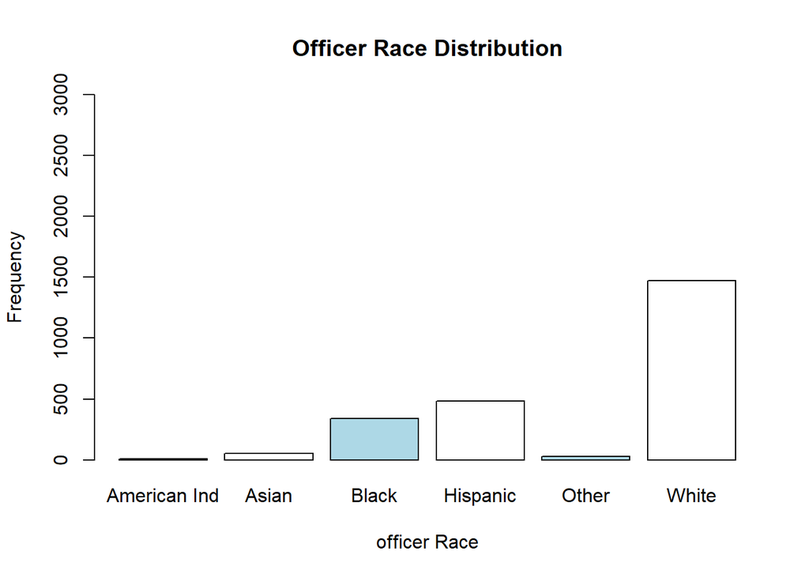

```
##
## American Ind        Asian        Black     Hispanic        Other        White
##    0.3357113    2.3080151   14.3096937   20.2266051    1.1330256   61.6869492
```

It was found total 234 number of times officers were injured.

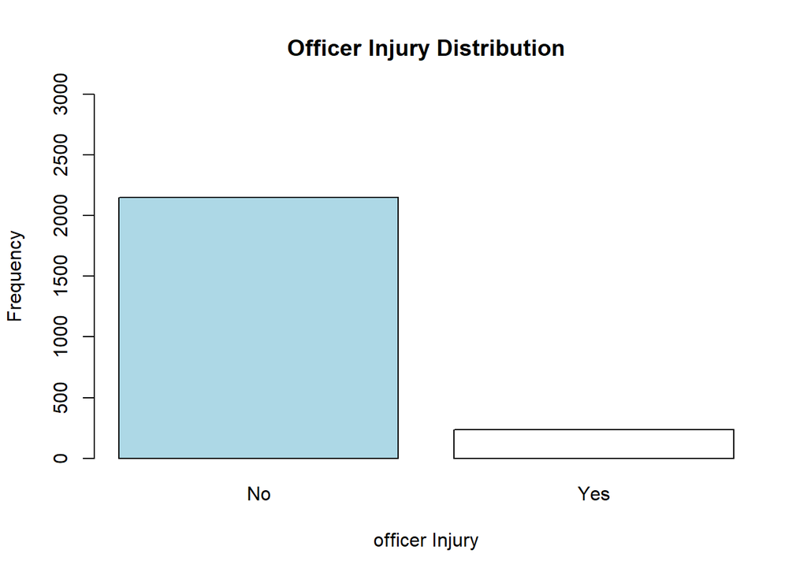

###### Summary Statistics of **OFFICER_INJURY**

```
##
##   No  Yes
## 2149  234
```

In this table it can be seen that out of total 234 injuries, 147 of them were of white officers. ###### Summary Statistics of **OFFICER_INJURY** & **OFFICER_RACE** variable ref[1]

```
##
##       American Ind Asian Black Hispanic Other White
##   No             8    47   310      438    23  1323
##   Yes            0     8    31       44     4   147
```

In the below tabel we can see that 1932 subjects gender were male.

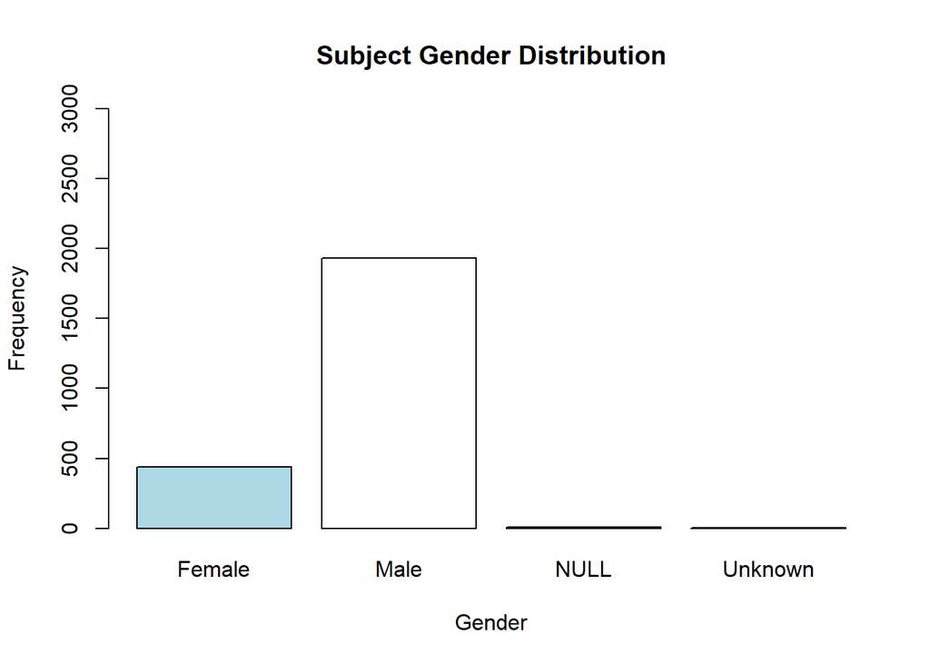

###### Summary Statistics of **SUBJECT_GENDER** ref[1]

```
##
##  Female    Male    NULL Unknown
##     440    1932      10       1
```

With all the cases reported in year 2016. Proportion of **black** people involved in crime activities was surprisingly as high as 55% ref[1].

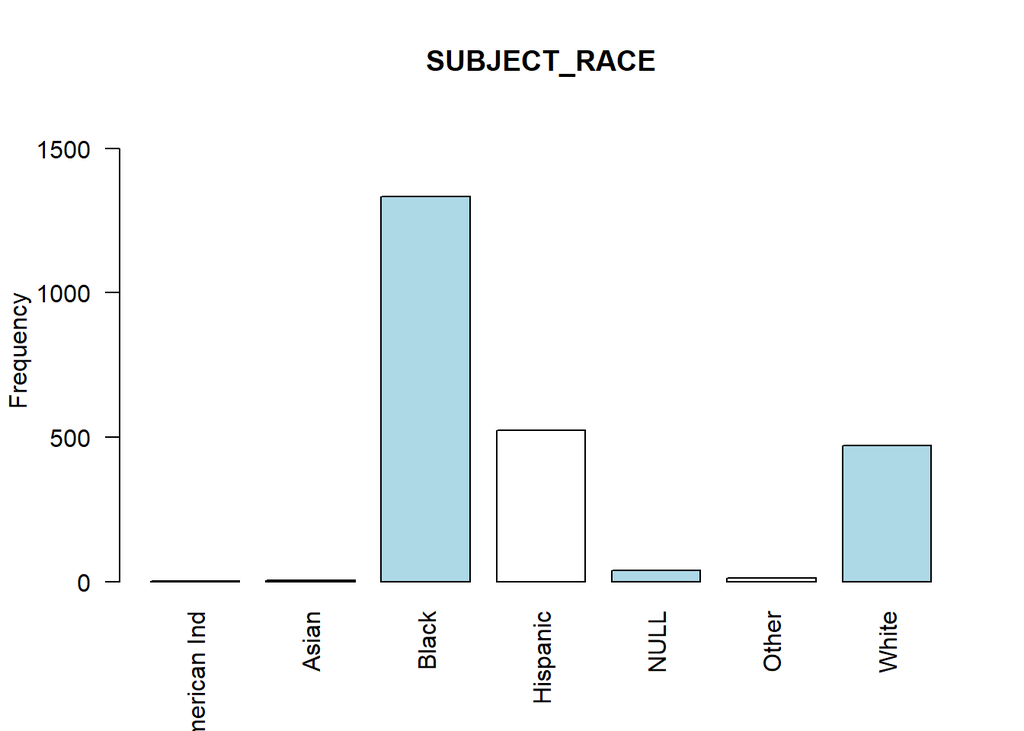

```
##
## American Ind        Asian        Black     Hispanic         NULL        Other
##   0.04196391   0.20981956  55.93789341  21.98908938   1.63659253   0.46160302
##        White
##  19.72303819
```

In the below table we can see that count black male involved in crime cases was 1058. ###### Summary Statistics of **SUBJECT_GENDER** & **SUBJECT_RACE** variable

```
##
##           American Ind Asian Black Hispanic NULL Other White
##   Female             0     0   274       69    4     0    93
##   Male               1     5  1058      455   25    11   377
##   NULL               0     0     0        0   10     0     0
##   Unknown            0     0     1        0    0     0     0
```

###### Summary Statistics of **SUBJECT_INJURY** ref[1]

```
##
##   No  Yes
## 1754  629
```

```
##
##       American Ind Asian Black Hispanic NULL Other White
##   No             1     5   999      398   25     7   319
##   Yes            0     0   334      126   14     4   151
```

In all the crime cases 2048 arrests were made in 2016.

###### Summary Statistics of **SUBJECT_WAS_ARRESTED** variable ref[1]

```
##
##   No  Yes
##  335 2048
```

```
##
##       American Ind Asian Black Hispanic NULL Other White
##   No             0     0   189       73   13     3    57
##   Yes            1     5  1144      451   26     8   413
```

###### Pergentage of **SUBJECT_WAS_ARRESTED** / **SUBJECT_RACE** variable ref[1]

```
##
##       American Ind       Asian       Black    Hispanic        NULL       Other
##   No    0.00000000  0.00000000  7.93117919  3.06336551  0.54553084  0.12589173
##   Yes   0.04196391  0.20981956 48.00671423 18.92572388  1.09106169  0.33571129
##
##             White
##   No   2.39194293
##   Yes 17.33109526
```

##### 2.3 Visulizaitons:

Crime had very close link with time. Below is time distribution of crimes reported between **1/1/2016 12:20:00 AM and 12/31/2016 11:19:00 PM** . There are very clear two spikes of increased crime at two different time stamps **17:00 PM and 20:00 PM**. First Spike at **(17:00 PM)** shows that more crime cases were reported after office hours, when people were heading towards there home and second spike at **(20:00 PM)** in the below graph shows that more crimes cases were reported when people are out for dinner ref[1].

#### —————————– Time Distribution of Crimes Reported——————————-

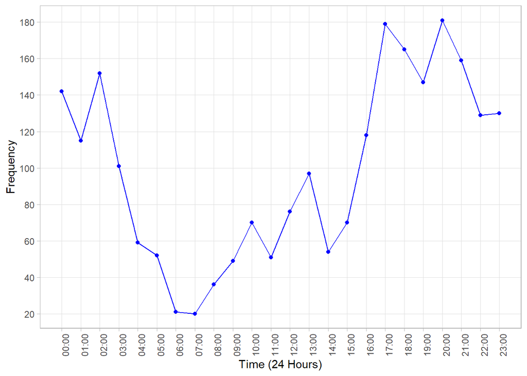

ref[1] ref[2] ref[8] ref[10] #### —————————– Distribution of Crime on Daily Basis —————————- It can be seen in the below chart that on average more crime cases were reported on weekend than the normal weekdays ref[1].

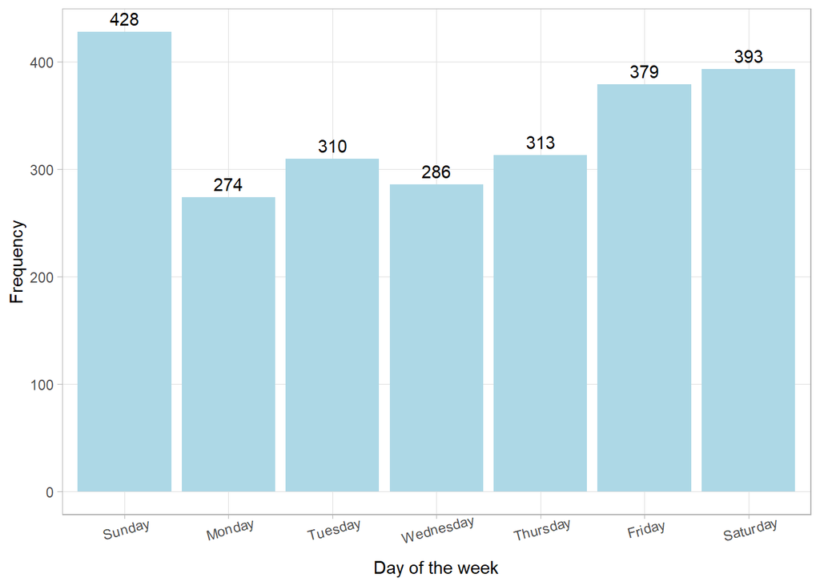

ref[1] ref[2] ref[8] ref[10]  
#### ————————— Hourly Distribution of Crimes on Daily Basis —————————

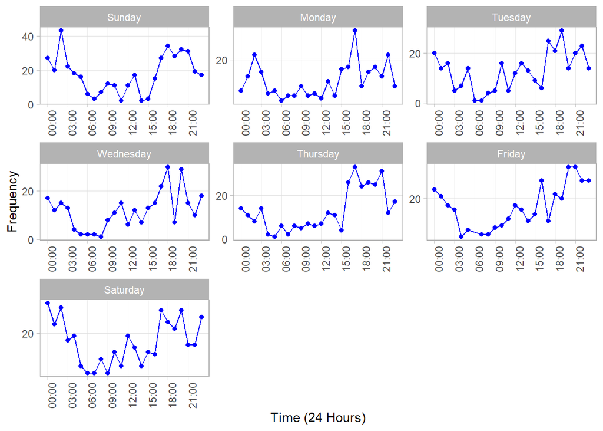

ref[1] ref[2] ref[8] ref[10]

#### ————————— GEO Location Distribution of Reports —————————

Location has very close link to the crime. Based on the below geo location distribution of crime, it is very clear that more crime cases were reported in the heart of city ref[1].

[interactive chart not shown]

ref[1] ref[4] ref[5] ref[6]

### Conclusions

In the conclusion it was derived from the very detailed analysis that day, time and location were the key factors in the all crimes that were reported in 2016. Its was also identified that some races were more involved in all the crime that were reported in 2016.

### References:

1- Course Work 1 code and summay statistics.  
2- Time Stamp: https://stackoverflow.com/questions/40345291/r-extract-hour-from-variable-format-timestamp?answertab=active#tab-top extract hours  
3- Calculating Mean, Standard Deviation, Frequencies, Summary Statistics > https://www.youtube.com/watch?v=ACWuV16tdhY  
4- Geo Location Distribution > https://rstudio.github.io/leaflet/markers.html  
5- Geo Location Distribution > https://handsondataviz.org/leaflet-maps-with-csv.html  
6- Geo Location Distribution > https://mapping-in-r.netlify.app/  
7- https://public.tableau.com/profile/ahmad.dajani#!/vizhome/AnalysisonBostonCrimes/MyStory  
8- https://www.youtube.com/watch?v=yzfgyV7oIxc  
9-https://www.youtube.com/watch?v=qI3vbzYrkJs  
10-https://www.youtube.com/watch?v=nRtp7wSEtJA&list=PLtL57Fdbwb_AWmWWrFV_pLqq2uicpUIO9